# Expanding Cluster Detection

# ——————————————————————————–

```r
campy_data <- c("MergedFinal_332calls_4203genomes_clusters.tsv",
                "MergedFinal_332calls_5075genomes_clusters.tsv")
X <- 1
Y <- 2

timepoint1 <- read.csv(file = campy_data[1], numerals = "no.loss",
                       stringsAsFactors = FALSE, sep = "\t") %>% as_tibble()
colnames(timepoint1) %<>% gsub(pattern = "genome", replacement = "isolate", x = .) %>%
  gsub(pattern = "X", replacement = "h_", x = .)

timepoint2 <- read.csv(file = campy_data[2], numerals = "no.loss",
                       stringsAsFactors = FALSE, sep = "\t") %>% as_tibble()
colnames(timepoint2) %<>% gsub(pattern = "genome", replacement = "isolate", x = .) %>%
  gsub(pattern = "X", replacement = "h_", x = .)
```

This report looks at the data comparing from 332calls_4203, at time point 1, to 332calls_5075, at time point 2. Replace the corresponding text in `threshold_files_chunk` if using different data.

# ——————————————————————————–

These are the isolates with designated clusters and corresponding cluster sizes at time point 1, for all heights. Sample rows of dataset below.

```r
clustersX <- timepoint1

sizes_for_tpX <- clusterSizes(clustersX)
tpX <- isolateClusterSize(clustersX, sizes_for_tpX) %>%
  set_colnames(c("isolate", "heights", "tpX_clusters", "tpX_sizes"))
rm(sizes_for_tpX)
```

```r
tpX[1:10,] %>%
  set_colnames(c("Isolates", "Heights", "Clusters", "Cluster Sizes")) %>%
  DT::datatable(., caption = "Sample rows of clusters and sizing",
                fillContainer = TRUE, filter = "top", rownames = FALSE,
                options = list(pageLength = 50, dom = "ti", scrollY = "500px",
                               columnDefs = list(list(className = "dt-center", targets = 1:3))))
```

| Isolates | Heights | Clusters | Cluster Sizes |
| --- | --- | --- | --- |
| CI_5823 | h_0 | 1 | 3 |
| CI_6737 | h_0 | 1 | 3 |
| CI_7152 | h_0 | 1 | 3 |
| CI_6852 | h_0 | 2 | 1 |
| CI_6833 | h_0 | 3 | 1 |
| CI_6935 | h_0 | 4 | 2 |
| CI_6942 | h_0 | 4 | 2 |
| 18_9561 | h_0 | 5 | 3 |
| CI_5783 | h_0 | 5 | 3 |
| CI_6979 | h_0 | 5 | 3 |

These are the isolates with designated clusters and corresponding cluster sizes at time point 2, for all heights. Sample rows of dataset below.

```r
clustersY <- timepoint2

sizes_for_tpY <- clusterSizes(clustersY)
tpY <- isolateClusterSize(clustersY, sizes_for_tpY) %>%
  set_colnames(c("isolate", "heights", "tpY_clusters", "tpY_sizes"))
rm(sizes_for_tpY)
```

```r
tpY[1:10,] %>%
  set_colnames(c("Isolates", "Heights", "Clusters", "Cluster Sizes")) %>%
  DT::datatable(., caption = "Sample rows of clusters and sizing",
                fillContainer = TRUE, filter = "top", rownames = FALSE,
                options = list(pageLength = 50, dom = "ti", scrollY = "500px",
                               columnDefs = list(list(className = "dt-center", targets = 1:3))))
```

| Isolates | Heights | Clusters | Cluster Sizes |
| --- | --- | --- | --- |
| CI_5823 | h_0 | 1 | 3 |
| CI_6737 | h_0 | 1 | 3 |
| CI_7152 | h_0 | 1 | 3 |
| CI_6852 | h_0 | 2 | 1 |
| CI_6833 | h_0 | 3 | 1 |
| CI_6935 | h_0 | 4 | 2 |
| CI_6942 | h_0 | 4 | 2 |
| 18_9561 | h_0 | 5 | 3 |
| CI_5783 | h_0 | 5 | 3 |
| CI_6979 | h_0 | 5 | 3 |

Some isolates occur in only one of the two time point datasets, so the following is to keep track of this.

```r
# setting up dataframe
d <- c(clustersX$isolate, clustersY$isolate) %>% unique() %>%
  tibble(Isolates = ., TPX = FALSE, TPY = FALSE, Both = FALSE)

# identifying isolates in one or both
d$TPY[which(d$Isolates %in% clustersY$isolate)] <- TRUE
d$TPX[which(d$Isolates %in% clustersX$isolate)] <- TRUE
d$Both[which(d$TPX & d$TPY)] <- TRUE

# preparing dataset for display
d <- d[order(d$Isolates),]
d$Isolates <- unique(d$Isolates) %>% sort() %>% factor(d$Isolates, levels = .)

d$TPX %<>% as.character()
d$TPY %<>% as.character()
d$Both %<>% as.character()
vals <- c("True", "False")

d[d == "TRUE"] <- vals[1]
d[d == "FALSE"] <- vals[2]

# table with colorful cells indicating where isolates are found
d %>% set_colnames(c("Isolates", paste0("Found in time point ", X, " dataset"),
                     paste0("Found in time point ", Y, " dataset"), "Found in both datasets")) %>%
  DT::datatable(., fillContainer = TRUE, filter = "top", rownames = TRUE,
                options = list(pageLength = nrow(d), dom = "ti", scrollY = "500px")) %>%
  formatStyle(2, backgroundColor = styleEqual(vals, c("lightsteelblue", "gray"))) %>%
  formatStyle(3, backgroundColor = styleEqual(vals, c("lightgreen", "gray"))) %>%
  formatStyle(4, backgroundColor = styleEqual(vals, c("lightsteelblue", "gray")))
```

|  | Isolates | Found in time point 1 dataset | Found in time point 2 dataset | Found in both datasets |
| --- | --- | --- | --- | --- |
| 1 | 00_2427 | True | True | True |
| 2 | 00_2428 | True | True | True |
| 3 | 00_2533 | True | True | True |
| 4 | 00_2842 | True | True | True |
| 5 | 00_2853 | True | True | True |
| 6 | 00_2861 | True | True | True |
| 7 | 00_3084 | True | True | True |
| 8 | 00_3086 | True | True | True |
| 9 | 00_3451 | True | True | True |
| 10 | 00_5077 | True | True | True |

[output cut: 5065 more lines]

# ——————————————————————————–

The following is a merged dataset of information on all isolates at all heights for both time points. There are labels for clusters that are now part of larger clusters (expanded = `larger`), those that are fragmented (`smaller`), and clusters whose size has not changed (`same`).

```r
# A merged dataset of information from both time points

tp <- full_join(tpX, tpY, by = c("isolate", "heights"))
tp$tpX_sizes[is.na(tp$tpX_sizes)] <- 0
tp$tpY_sizes[is.na(tp$tpY_sizes)] <- 0

tp$both <- tp$size_difference <- tp$tpY_sizes - tp$tpX_sizes

h_values <- tp$heights %>% unique()
num_h <- gsub("h_", "", h_values) %>% as.numeric() %>% tibble(heights = h_values, h = .)

tp <- left_join(tp, num_h, by = "heights")
tp <- tp[,c(1,9,2:8)]

inds_larger <- tp$both > 0
inds_same <- tp$both == 0
inds_smaller <- tp$both < 0

tp$both[inds_larger] <- "larger"
tp$both[inds_same] <- "same"
tp$both[inds_smaller] <- "smaller"

tp$tpX_clusters[is.na(tp$tpX_clusters)] <- "NA"
tp$tpY_clusters[is.na(tp$tpY_clusters)] <- "NA"

saveRDS(tp, "both_timepoints.Rds")
```

This dataset is too large to show in a table without server-side processing, so here are a few sample rows to see if this is the kind of setup we would like to improve on or remove entirely.

```r
tp[1:100,c(1,3:9)] %>% # -"Numeric height",
  set_colnames(c("Isolates", "Height label",
    paste0("Clusters at time point ", X), paste0("Cluster sizes at time point ", X),
    paste0("Clusters at time point ", Y), paste0("Cluster sizes at time point ", Y),
    paste0("Cluster size difference (TP ", Y, " - TP ", X, ")"),
    "Cluster expansion label")) %>%
  DT::datatable(., caption = paste0("Absolute labelling (larger/smaller/same size, ",
                                    "even minor size changes are noted), the first 100 rows"),
                fillContainer = TRUE, filter = "top", rownames = FALSE,
                options = list(pageLength = 50, dom = "ti", scrollY = "500px",
                               columnDefs = list(list(className = "dt-center", targets = 1:7))))
```

| Isolates | Height label | Clusters at time point 1 | Cluster sizes at time point 1 | Clusters at time point 2 | Cluster sizes at time point 2 | Cluster size difference (TP 2 - TP 1) | Cluster expansion label |
| --- | --- | --- | --- | --- | --- | --- | --- |
| CI_5823 | h_0 | 1 | 3 | 1 | 3 | 0 | same |
| CI_6737 | h_0 | 1 | 3 | 1 | 3 | 0 | same |
| CI_7152 | h_0 | 1 | 3 | 1 | 3 | 0 | same |
| CI_6852 | h_0 | 2 | 1 | 2 | 1 | 0 | same |
| CI_6833 | h_0 | 3 | 1 | 3 | 1 | 0 | same |
| CI_6935 | h_0 | 4 | 2 | 4 | 2 | 0 | same |
| CI_6942 | h_0 | 4 | 2 | 4 | 2 | 0 | same |
| 18_9561 | h_0 | 5 | 3 | 5 | 3 | 0 | same |
| CI_5783 | h_0 | 5 | 3 | 5 | 3 | 0 | same |
| CI_6979 | h_0 | 5 | 3 | 5 | 3 | 0 | same |

[output cut: 90 more lines]

Table of heights and clusters, with specific (and at the moment arbitrary) requirements. Goal: to identify what kind of change in size can be expected, given the number of isolates at each time point, the number of clusters at a height (will need to check a variety of heights, maybe a randomly selected set), and inflation of false positives due to multiple comparison testing (WIP).

```r
min_size <- 20  # minimum initial cluster size to filter for
min_dif <- 100  # minimum change in cluster size to filter for
```

```r
df_expanding <- tp %>%
  filter(tpX_sizes >= min_size) %>%
  filter(both == "larger") %>%
  filter(size_difference > min_dif) %>%
  dplyr::select(h, heights, tpX_clusters, tpX_sizes, tpY_clusters, tpY_sizes, size_difference) %>%
  unique()

df_expanding[,2:7] %>% # - "Numeric height",
  set_colnames(c("Height label", paste0("Cluster at time point ", X),
                 paste0("Cluster size at time point ", X), paste0("Cluster at time point ", Y),
                 paste0("Cluster size at time point ", Y), "Difference in size")) %>%
  DT::datatable(., caption = paste0("Clusters that have size >= ", min_size,
                                    " and change in size ", "from TP", X,
                                    " to TP", Y, " by at least ", min_dif, " isolates"),
                fillContainer = TRUE, filter = "top", rownames = TRUE,
                options = list(pageLength = nrow(df_expanding), dom = "ti", scrollY = "500px",
                               columnDefs = list(list(className = "dt-center", targets = 0:6))))
```

|  | Height label | Cluster at time point 1 | Cluster size at time point 1 | Cluster at time point 2 | Cluster size at time point 2 | Difference in size |
| --- | --- | --- | --- | --- | --- | --- |
| 1 | h_10 | 537 | 22 | 339 | 132 | 110 |
| 2 | h_97 | 18 | 68 | 16 | 205 | 137 |
| 3 | h_98 | 18 | 68 | 16 | 205 | 137 |
| 4 | h_134 | 136 | 427 | 174 | 545 | 118 |
| 5 | h_134 | 137 | 70 | 174 | 545 | 475 |
| 6 | h_135 | 135 | 427 | 172 | 545 | 118 |
| 7 | h_135 | 136 | 70 | 172 | 545 | 475 |
| 8 | h_136 | 134 | 427 | 171 | 545 | 118 |
| 9 | h_136 | 135 | 70 | 171 | 545 | 475 |
| 10 | h_137 | 133 | 427 | 170 | 545 | 118 |

[output cut: 240 more lines]

# ——————————————————————————–

Notes to self on the plot:  
* ymax - upper whisker = largest observation less than or equal to upper hinge + 1.5 * IQR  
* upper - upper hinge, 75% quantile  
* notchupper - upper edge of notch = median + 1.58 * IQR / sqrt(n)  
* middle - median, 50% quantile  
* notchlower - lower edge of notch = median - 1.58 * IQR / sqrt(n)  
* lower - lower hinge, 25% quantile  
* ymin - lower whisker = smallest observation greater than or equal to lower hinge - 1.5 * IQR

```r
tp <- tp %>% arrange(., h)
tp$heights <- factor(tp$heights, levels = unique(tp$heights))
num_h_vals <- tp$h %>% unique()
```

Note that “negative changes in cluster size” are because some isolates are clustered into different, smaller clusters at the second time point than at they are at the first time point.

## Boxplots of cluster size changes

```r
# Note: this plot looks at a subset of heights, spaced at even increments (can reduce the spacing
# if you want to see more heights). Note that the plot is less clear for smaller increment sizes.
# increment_size <- 1
height_list <- tp$heights %>% unique()
```

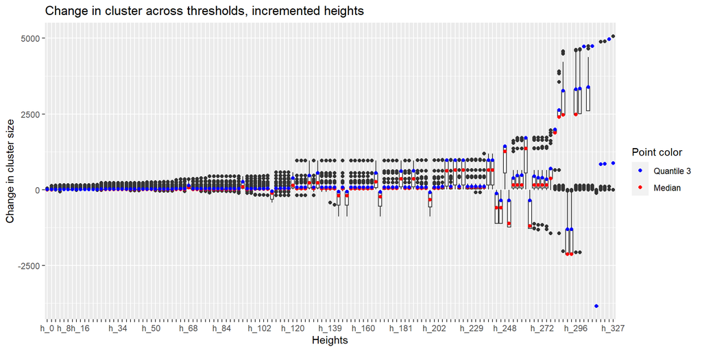

```r
tp %>% filter(heights %in% height_list[seq(1, 274, 2)]) %>% boxplotSubset(., ", incremented heights")
```

### Heights 1 - 50

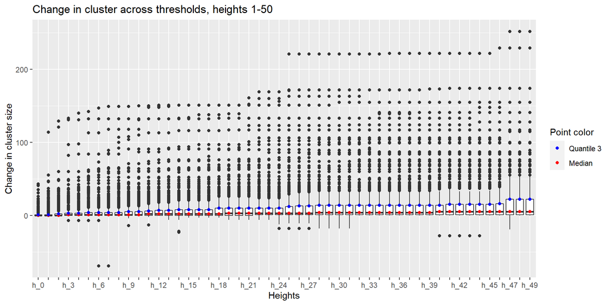

```r
tp %>% filter(heights %in% height_list[1:50]) %>% boxplotSubset(., ", heights 1-50")
```

### Heights 51 - 100

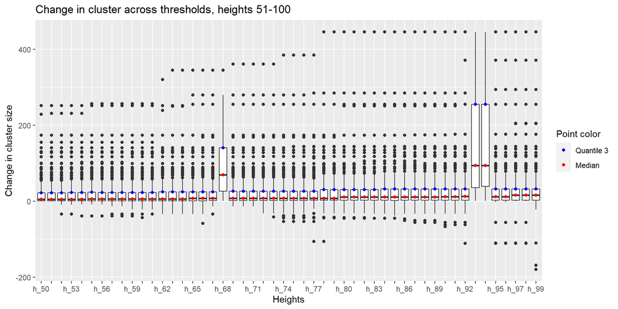

```r
tp %>% filter(heights %in% height_list[51:100]) %>% boxplotSubset(., ", heights 51-100")
```

### Heights 101 - 150

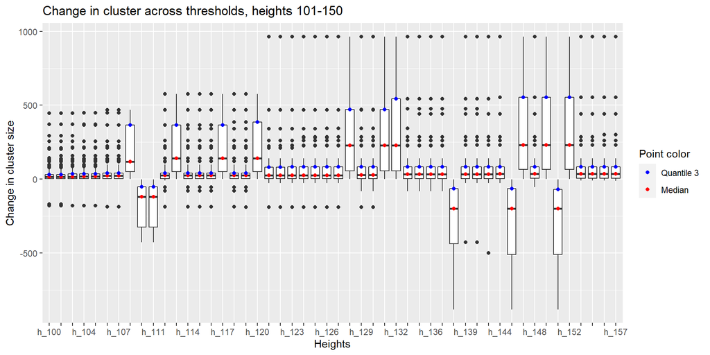

```r
tp %>% filter(heights %in% height_list[101:150]) %>% boxplotSubset(., ", heights 101-150")
```

### Heights 151 - 200

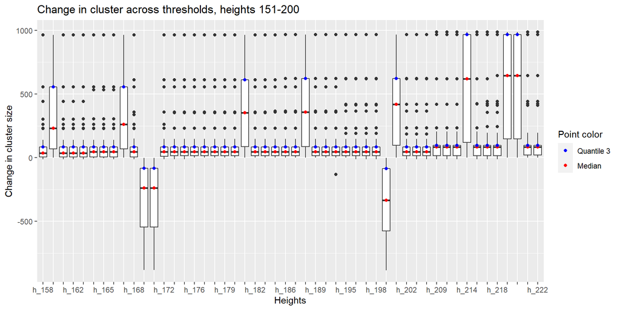

```r
tp %>% filter(heights %in% height_list[151:200]) %>% boxplotSubset(., ", heights 151-200")
```

### Heights 201 - 274

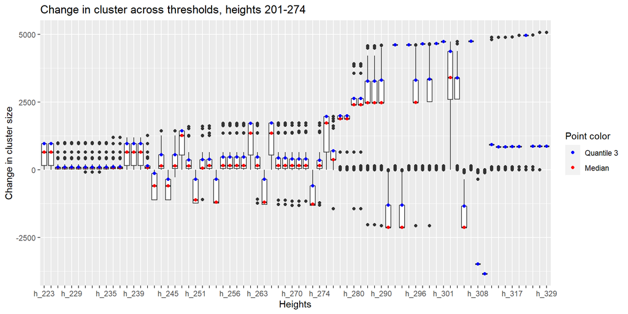

```r
tp %>% filter(heights %in% height_list[201:274]) %>% boxplotSubset(., ", heights 201-274")
```

Example of data that results in a smaller cluster at time point 2 (h_7 in the above plot).

```r
smaller_eg <- tp %>% dplyr::select(-h) %>%
  filter(heights == "h_7")
smaller_eg[order(smaller_eg$both, decreasing = TRUE),] %>%
  set_colnames(c("Isolates", "Height label",
                 paste0("Clusters at time point ", X),
                 paste0("Cluster sizes at time point ", X),
                 paste0("Clusters at time point ", Y),
                 paste0("Cluster sizes at time point ", Y),
                 paste0("Cluster size difference (TP ", Y, " - TP ", X, ")"),
                 "Cluster expansion label")) %>%
  DT::datatable(., caption = paste0("Absolute labelling (larger/smaller/same size, ",
                                    "even minor size changes are noted)"),
                fillContainer = TRUE, filter = "top", rownames = FALSE,
                options = list(pageLength = 50, dom = "ti", scrollY = "500px",
                               columnDefs = list(list(className = "dt-center", targets = 1:7))))
```

| Isolates | Height label | Clusters at time point 1 | Cluster sizes at time point 1 | Clusters at time point 2 | Cluster sizes at time point 2 | Cluster size difference (TP 2 - TP 1) | Cluster expansion label |
| --- | --- | --- | --- | --- | --- | --- | --- |
| A3GP_2020_768 | h_7 | 636 | 70 | 834 | 1 | -69 | smaller |
| CI_5823 | h_7 | 1 | 12 | 1 | 12 | 0 | same |
| CI_6737 | h_7 | 1 | 12 | 1 | 12 | 0 | same |
| CI_7152 | h_7 | 1 | 12 | 1 | 12 | 0 | same |
| CI_6852 | h_7 | 1 | 12 | 1 | 12 | 0 | same |
| CI_6833 | h_7 | 1 | 12 | 1 | 12 | 0 | same |
| CI_6935 | h_7 | 1 | 12 | 1 | 12 | 0 | same |
| CI_6942 | h_7 | 1 | 12 | 1 | 12 | 0 | same |
| 18_9561 | h_7 | 1 | 12 | 1 | 12 | 0 | same |
| CI_5783 | h_7 | 1 | 12 | 1 | 12 | 0 | same |

[output cut: 5065 more lines]